# Research Methods in Developmental Linguistics: Analyzing experimental data

## Using an RStudio Notebook

Notebooks combine text, code, figures, analysis results in a single readable file, which you can easily use when you’re ready to write up.

You’ll see here that there is text (with some formatting), and then code ‘Chunks’ (inserted using Code > Insert Chunk), with the resulting output beneath them. You can run all the code, or a portion of the code, or just individual chunks using the Run button, or the little green ‘play’ arrows in each code Chunk.

To preview your notebook, choose Tools > Global Options > R Markdown > Show output preview in viewer pane (or Window if you want to appear in an external window).

To output your notebook as an html file, pdf, or word document, choose Knit then the format you want.

## Getting ready

There are a couple of things you need to do before you get started analyzing your data.

1. Change your working directory
2. Load any packages you might need
3. Load your data

### Setting or changing your working directory

If you are using an RStudio notebook, the working directory will automatically be set to the directory the notebook is saved in.

Otherwise, to set your working directory for easy access to the files you’re going to use, and to save any output to that same folder, use the following PC or Mac commands:

```r
#setwd("C:/Users/User Name/Documents/FOLDER")
#setwd("/Users/User Name/Documents/FOLDER")
```

You will need to substitute the path name of the directory you want. If you don’t know your directory name, you can ask for the current directory using:

```r
#getwd()
```

Or you can use Misc > Change Working Directory on a Mac, or File > Change Working Directory on a PC.

I usually navigate to mine using a little shortcut that covers the “/Users/User Name/” part on a Mac and the “C:/Users/User Name/Documents” part on a PC.

```r
#setwd("~/Google Drive/Teaching/ResearchMethodsDevLing/Analyzing")
```

### Loading packages and data

Now we are ready to load some stuff! First, we’ll load the plotting package we need, and also a helpful package for getting descriptive statistics:

```r
library(ggplot2)
library(plyr)
```

Next, we’ll read in the data to be analyzed:

```r
data = read.csv("alldata.csv") #check out the other arguments you could add to this
```

This will create a data structure called a ‘dataframe’. The first thing I always do is having a look at the first few lines of the dataframe and make sure it looks as I expected:

```r
head(data)
```

|  | colour | congruence | word | corrAns | trials.thisRepN | trials.thisTrialN | trials.thisN | trials.thisIndex | response.keys | response.corr | response.rt | date | group | participant |
| --- | --- | --- | --- | --- | --- | --- | --- | --- | --- | --- | --- | --- | --- | --- |
| 1 | green | 1 | green | down | 0 | 0 | 0 | 2 | left | 0 | 6.343373 | 2016_Jan_26_1905 | B | 1 |
| 2 | blue | 0 | green | right | 0 | 1 | 1 | 3 | right | 1 | 2.580500 | 2016_Jan_26_1905 | B | 1 |
| 3 | red | 1 | red | left | 0 | 2 | 2 | 0 | left | 1 | 4.526279 | 2016_Jan_26_1905 | B | 1 |
| 4 | blue | 1 | blue | right | 0 | 3 | 3 | 4 | right | 1 | 2.240764 | 2016_Jan_26_1905 | B | 1 |
| 5 | green | 0 | red | down | 0 | 4 | 4 | 1 | down | 1 | 3.075916 | 2016_Jan_26_1905 | B | 1 |
| 6 | red | 0 | blue | left | 0 | 5 | 5 | 5 | left | 1 | 2.359008 | 2016_Jan_26_1905 | B | 1 |

We can also have a look at it using a simple summary function, which tells us what columns are in the dataframe, and whether they are ‘factors’ or not. A ‘factor’ is an independent (predictor) variable, with some number of discrete/categorical levels. Numerical IVs are treated differently (as ‘num’ or ‘int’).

```r
str(data)
```

```
## 'data.frame':    300 obs. of  14 variables:
##  $ colour           : Factor w/ 3 levels "blue","green",..: 2 1 3 1 2 3 2 3 2 3 ...
##  $ congruence       : int  1 0 1 1 0 0 1 0 0 1 ...
##  $ word             : Factor w/ 3 levels "blue","green",..: 2 2 3 1 3 1 2 1 3 3 ...
##  $ corrAns          : Factor w/ 3 levels "down","left",..: 1 3 2 3 1 2 1 2 1 2 ...
##  $ trials.thisRepN  : int  0 0 0 0 0 0 1 1 1 1 ...
##  $ trials.thisTrialN: int  0 1 2 3 4 5 0 1 2 3 ...
##  $ trials.thisN     : int  0 1 2 3 4 5 6 7 8 9 ...
##  $ trials.thisIndex : int  2 3 0 4 1 5 2 5 1 0 ...
##  $ response.keys    : Factor w/ 3 levels "down","left",..: 2 3 2 3 1 2 1 3 1 2 ...
##  $ response.corr    : int  0 1 1 1 1 1 1 0 1 1 ...
##  $ response.rt      : num  6.34 2.58 4.53 2.24 3.08 ...
##  $ date             : Factor w/ 9 levels "2016_Jan_25_1511",..: 9 9 9 9 9 9 9 9 9 9 ...
##  $ group            : Factor w/ 2 levels "A","B": 2 2 2 2 2 2 2 2 2 2 ...
##  $ participant      : int  1 1 1 1 1 1 1 1 1 1 ...
```

Now, what do you notice about the ‘congruence’ column in the dataframe? Is R treating this variable in the way we might want? Do you see any others that are problematic?

Right, so if we want to use these as factors to predict the participants’ responses, then we need to tell R they should be factors:

```r
data$congruence = as.factor(data$congruence)
data$participant = as.factor(data$participant)
```

The classification of the dependent variable should remain ‘int’ since we actually what to use 1 and 0 to calculate things like mean, standard deviation, etc.

## Brief note on reading in data files

Reading in data files is one of the most frustrating aspects of R. Here are some tips on how to structure your input file, and what to look for if something goes wrong:

1. Don’t use any special characters, (#, *, >, ?, “”, ’, $, etc.) ANYWHERE.
2. Be careful with commas! These are the default column separator in read.csv, but if you need to use commas for something else (e.g., decimals), then use `read.table()`, and specify sep=‘\t’
3. Don’t leave empty cells or columns (if necessary fill in with `NA`, and use `rm.na=True` in your function calls)
4. If you don’t get the right number of columns, or you see lots of NA’s, then you probably typed a random character somewhere in the periphery of your spreadsheet.
5. Remember: by default R will treat numbers as numeric or integer data.

## Flashback: basic descriptive statistics

Before we do anything more advanced, let’s take a moment to remember some basics:

1. Mode: value that occurs the most frequently
2. Median: value separating higher and lower half of the sample
3. Mean: average value
4. Range: highest and lowest values
5. Variance: measure of data dispersion
6. Standard deviation (SD): square root of the variance
7. Standard error of the mean (SE): standard deviation of the sampling distribution (i.e., how much variation we expect in the mean between different “runs” of our experiment)

```r
table(round(data$response.rt))
```

```
##
##   0   1   2   3   4   5   6   8   9
##  26 229  30   7   1   3   2   1   1
```

```r
median(data$response.rt)
```

```
## [1] 0.7814761
```

So, half of the RT values are below, and half are above that value. We can see that if we plot a histogram of the RT data.

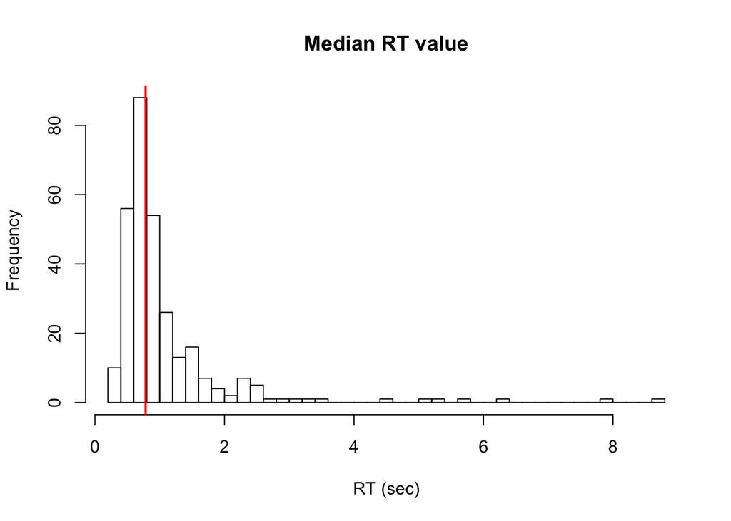

```r
hist(data$response.rt, breaks = 30, main="Median RT value",xlab="RT (sec)")
abline(v=median(data$response.rt), lwd=2, col="red")
```

That’s different from the mean, which is the average value (sum of all values, divided by the number of values). Why do you think the mean is so much higher than the median for this data?

```r
mean(data$response.rt)
```

```
## [1] 1.072821
```

We can see from our histograph that the full range of the data is pretty large.

```r
range(data$response.rt)
```

```
## [1] 0.3268672 8.6967610
```

There are various ways to measure data ‘dispersion’. The simplest is called the variance: the sum of squared ‘residuals’ (difference between each value and the mean), taking into account the sample size.

```r
var(data$response.rt)
```

```
## [1] 0.9742443
```

We can also calculate the standard deviation, that’s just the square root of the variance – it’s useful because it can tell us how far off the mean a given point is.

```r
sd(data$response.rt)
```

```
## [1] 0.9870381
```

Like, how weird is the longest RT value, 8.69? In these terms, how many SD’s away from the mean is it?

```r
(8.69 - mean(data$response.rt))/sd(data$response.rt)
```

```
## [1] 7.717208
```

Speaking of outliers…

## Preliminaries: dealing with outliers in RT data

We can see from our histogram that most of the data are clustered around a small range of values, and then there are a few which are way out there, right? Turns out that when you collect RT data, you need to be careful about ‘outliers’ – data points that are out of the range of typical responses, which we don’t want to include in the data. There are a couple of different ways to do this.

### Method 1: visually inspect the RTs and decide on a cut-off point.

Let’s look at the histogram again.

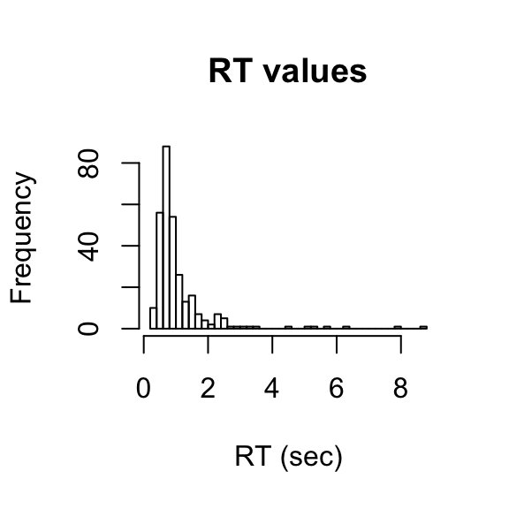

```r
hist(data$response.rt, breaks = 30, main="RT values",xlab="RT (sec)")
```

Does it look like there’s a natural point where the distribution should tail off? You can set the cut-off point there, and exclude rows from the data with RT higher than that point.

```r
cutoff =  4
trimmedRT = subset(data, response.rt < cutoff)
```

We might want to know how may got excluded when we do this, or what percentage of the data were lost.

```r
length(data$response.rt) - length(trimmedRT$response.rt) # how many got excluded?
```

```
## [1] 7
```

```r
(length(data$response.rt) - length(trimmedRT$response.rt))/length(data$response.rt)*100 # what % was lost?
```

```
## [1] 2.333333
```

### Method 2: Use a cutoff point based on means and SDs

To do this, first calculate the mean RT and SD from the mean for each participant by condition:

```r
RT.sum = ddply(data, c("participant", "congruence"), summarise, RT.mean = mean(response.rt), RT.sd = sd(response.rt))

head(RT.sum)
```

|  | participant | congruence | RT.mean | RT.sd |
| --- | --- | --- | --- | --- |
| 1 | 1 | 0 | 1.7480671 | 0.6067870 |
| 2 | 1 | 1 | 2.0291641 | 1.5152579 |
| 3 | 2 | 0 | 0.8380087 | 0.2114637 |
| 4 | 2 | 1 | 0.7775959 | 0.2050998 |
| 5 | 3 | 0 | 1.0199691 | 0.5604956 |
| 6 | 3 | 1 | 0.6162289 | 0.1766971 |

That will give you a new dataframe, with mean and SD RT values for each participant, for congruent and incongruent trials. If we merge this with the data, it will tack on the mean and SD values for every row.

```r
data = merge(data, RT.sum)
head(data)
```

|  | congruence | participant | colour | word | corrAns | trials.thisRepN | trials.thisTrialN | trials.thisN | trials.thisIndex | response.keys | response.corr | response.rt | date | group | RT.mean | RT.sd |
| --- | --- | --- | --- | --- | --- | --- | --- | --- | --- | --- | --- | --- | --- | --- | --- | --- |
| 1 | 0 | 1 | green | red | down | 2 | 2 | 14 | 1 | down | 1 | 1.592396 | 2016_Jan_26_1905 | B | 1.748067 | 0.606787 |
| 2 | 0 | 1 | blue | green | right | 2 | 0 | 12 | 3 | right | 1 | 1.174718 | 2016_Jan_26_1905 | B | 1.748067 | 0.606787 |
| 3 | 0 | 1 | blue | green | right | 0 | 1 | 1 | 3 | right | 1 | 2.580500 | 2016_Jan_26_1905 | B | 1.748067 | 0.606787 |
| 4 | 0 | 1 | red | blue | left | 0 | 5 | 5 | 5 | left | 1 | 2.359008 | 2016_Jan_26_1905 | B | 1.748067 | 0.606787 |
| 5 | 0 | 1 | red | blue | left | 1 | 1 | 7 | 5 | right | 0 | 1.142009 | 2016_Jan_26_1905 | B | 1.748067 | 0.606787 |
| 6 | 0 | 1 | green | red | down | 3 | 2 | 20 | 1 | down | 1 | 1.525818 | 2016_Jan_26_1905 | B | 1.748067 | 0.606787 |

Now, decide where you want to set the cutoff point using some measure: mean+2SD, mean+2.5SD, mean+3SD are commonly used. In this example, we have set it to mean+2SD. Then we take the subset of the data where the response for a given trial is less than 2 SDs from the mean (for that participant). That will get rid of any trials where the RT is greater than that.

```r
trimmedRT = subset(data, response.rt < (RT.mean + 2*RT.sd))
```

Again we can see how may got excluded and what percentage of the data were lost for this method.

```r
length(data$response.rt) - length(trimmedRT$response.rt) # how many got excluded?
```

```
## [1] 19
```

```r
(length(data$response.rt) - length(trimmedRT$response.rt))/length(data$response.rt)*100 # what % was lost?
```

```
## [1] 6.333333
```

## Getting descriptive statistics

### Reaction time data

After we remove outliers, we can look at the mean RTs per participant and condition again. When we do this, we should include the group information for the participants – A or B (native or non-native).

Note that it is standard practice to exclude all incorrect responses from the calculation of mean RTs.

```r
NoErrors = subset(trimmedRT, response.corr == 1)
(length(data$response.rt) - length(NoErrors$response.rt))/length(data$response.rt)*100 # % of trials TOTAL now excluded from the original?
```

```
## [1] 13
```

Now use the same function as above to calculate mean RT by group, participant, and trial type (congruent or incongruent):

```r
MeanRT = ddply(NoErrors, c("group", "participant", "congruence"), summarise, RT = mean(response.rt))
MeanRT # let's see it
```

| group | participant | congruence | RT |
| --- | --- | --- | --- |
| A | 2 | 0 | 0.9765955 |
| A | 2 | 1 | 0.7426478 |
| A | 4 | 0 | 1.0549725 |
| A | 4 | 1 | 0.7217065 |
| A | 5 | 0 | 0.6659643 |
| A | 5 | 1 | 1.5582370 |
| A | 8 | 0 | 1.0155565 |
| A | 8 | 1 | 0.7120888 |
| B | 1 | 0 | 1.6925448 |
| B | 1 | 1 | 1.7210064 |

[output cut: 10 more lines]

That gives us an idea of how each individual participant behaves. We can use this dataframe later to run our statistical analysis.

But we also need summarise the RT data further, calculating the mean and SD by group and condition. We will also add standard error because we’re going to use this dataframe to plot the data later on.

```r
SummaryRT = ddply(MeanRT, c("group", "congruence"), summarise, N = length(RT), mean = mean(RT), sd = sd(RT))
SummaryRT$se = SummaryRT$sd/sqrt(SummaryRT$N) # This adds standard errors
SummaryRT #check it out!
```

| group | congruence | N | mean | sd | se |
| --- | --- | --- | --- | --- | --- |
| A | 0 | 4 | 0.9282722 | 0.1777752 | 0.08888761 |
| A | 1 | 4 | 0.9336700 | 0.4165734 | 0.20828670 |
| B | 0 | 6 | 0.9716904 | 0.3819862 | 0.15594522 |
| B | 1 | 6 | 0.9385143 | 0.4121505 | 0.16825973 |

If you wanted, you could output this to a file (it’ll go in the directory you specified above):

```r
write.csv(SummaryRT, file = "SummaryRT.csv")
```

### Accuracy data

We can also look at accuracy (this time not excluding incorrect responses of course). First by group, participant, and condition:

```r
MeanAcc = ddply(data, c("participant","group","congruence"), summarise, Acc = mean(response.corr))
```

Then summarizing further, calculating the mean and SD by group and condition, plus SE (for use in plotting):

```r
SummaryAcc = ddply(MeanAcc, c("group", "congruence"), summarise, N = length(Acc), mean = mean(Acc), sd = sd(Acc))
SummaryAcc$se = SummaryAcc$sd/sqrt(SummaryAcc$N) # This adds standard errors
SummaryAcc #check it out!
```

| group | congruence | N | mean | sd | se |
| --- | --- | --- | --- | --- | --- |
| A | 0 | 4 | 0.8000000 | 0.35694174 | 0.17847087 |
| A | 1 | 4 | 0.9666667 | 0.06666667 | 0.03333333 |
| B | 0 | 6 | 0.9444444 | 0.05018484 | 0.02048788 |
| B | 1 | 6 | 0.9555556 | 0.03442652 | 0.01405457 |

## Visualizing the results

Here we will use bar plots, showing means with error bars for standard errors.

### Plot of RT data

Note that we are using the dataframe `SummaryRT` that we created above.

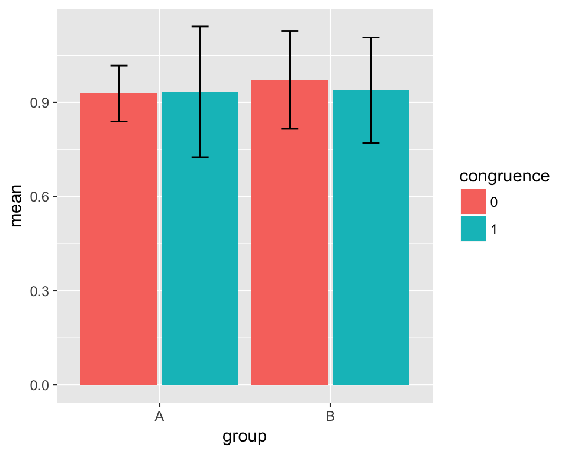

```r
  ggplot(SummaryRT, aes(x = group, y = mean, fill = congruence)) +
  geom_bar(position=position_dodge(0.95), stat="identity") +
  geom_errorbar(aes(ymin=mean-se, ymax=mean+se),
                width=.2,
                position=position_dodge(.95))
```

### Plot of accuracy data.

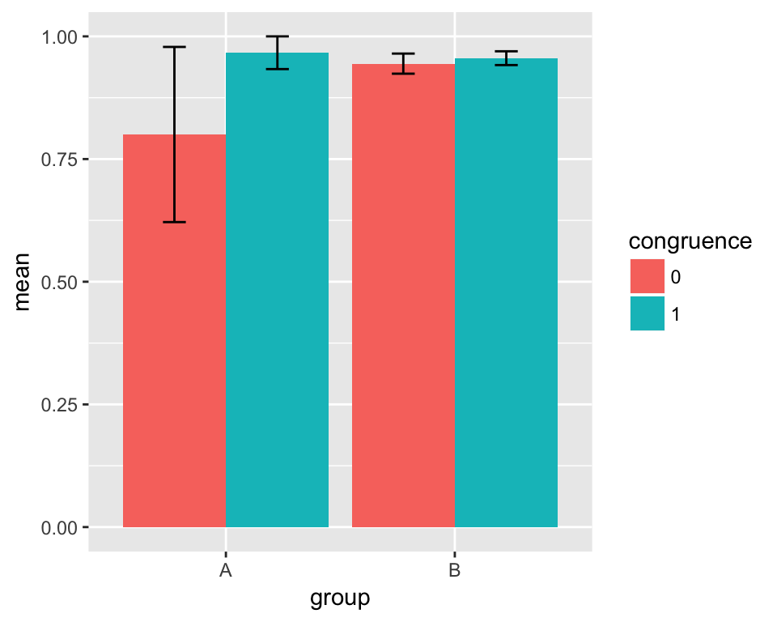

```r
  ggplot(SummaryAcc, aes(x = group, y = mean, fill = congruence)) +
  geom_bar(position=position_dodge(), stat="identity") +
  geom_errorbar(aes(ymin=mean-se, ymax=mean+se),
                width=.2,
                position=position_dodge(.9))
```

### Plot customization and saving

If you want to change the legends, labels, titles etc. see the relevant pages here: http://www.cookbook-r.com/Graphs/

To save your plot, you can use the following code, placed right after the plot you want to save:

```r
ggsave("Accuracy.jpg", device="jpg")
```

## Running statistics

Today, we are going to run an ANOVA (Analysis of Variance). The design of the experiment is a 2 x 2 mixed-design.

It’s mixed because there is a within-subjects factors (congruence), and a between-subjects factor (group).

It’s 2 x 2, because each of these factors has two levels: group (A, B) and congruence (0, 1). Participants in each level of the between-subject factor (group) get each level of the within-subjects factor (congruence). In other words, the within-subjects factor is repeated measures.

### ANOVA for RT data

For the RT analysis, we can use the dataframe `MeanRT` that we created above (including by-participant means!).

The dependent variable is `RT`.

So, when we construct our ANOVA model, we are going to be trying to predict RT from our two predictor variables, group and congruence. That’s the first part of the function call below `RT ~ group + congruence`.

The second part of the function call is what tells R that this is repeated measures data. That’s important, because it causes the model to take into account the fact that the two values we get for each participant are not independent–they are both measured from the same person, so if that person is in general quite fast, we expect both congruent and incongruent trials to be relatively fast. Put another way, we assume their means will be *correlated* across trial type.

In ANOVA terms, this means specifying how to quantify the residual error, or variance in the data that will be due not to the factors of interest, but to individual differences among participants. In `Error(A/B)`, A refers to the factor that is undergoing the repetition (here, the participants) and B refers to the factor that is repeated within A (here, congruence).

```r
anova_RT = aov(RT ~ group + congruence + Error(participant/congruence), data=MeanRT)
summary(anova_RT)
```

```
##
## Error: participant
##           Df Sum Sq Mean Sq F value Pr(>F)
## group      1 0.0028  0.0028   0.014  0.908
## Residuals  8 1.5597  0.1950
##
## Error: participant:congruence
##            Df Sum Sq Mean Sq F value Pr(>F)
## congruence  1 0.0016 0.00157   0.022  0.885
## Residuals   9 0.6364 0.07071
```

This first model estimates the ‘main effect’ of group, and the ‘main effect’ of congruence, without any interaction between the two. That means the model assumes that the effect of group doesn’t change with the levels of the factor congruence.

But one could easily imagine data where this is NOT the case – in other words, where the effect of group differs depending on whether the trial type is congruent or incongruent. Maybe both groups are relatively fast for congruent trials, but for incongruent trials, the native-English-speaking group gets slower but the non-native group doesn’t…Hey, that was our hypothesis!

To test that, we need to add the interaction term into our model. We do that by changing from `+` to `*`.

```r
anova_RT = aov(RT ~ group * congruence + Error(participant/congruence), data=MeanRT)
summary(anova_RT)
```

```
##
## Error: participant
##           Df Sum Sq Mean Sq F value Pr(>F)
## group      1 0.0028  0.0028   0.014  0.908
## Residuals  8 1.5597  0.1950
##
## Error: participant:congruence
##                  Df Sum Sq Mean Sq F value Pr(>F)
## congruence        1 0.0016 0.00157   0.020  0.891
## group:congruence  1 0.0018 0.00179   0.023  0.884
## Residuals         8 0.6346 0.07933
```

In this case, neither the main effects nor the interaction are significant. Them’s the breaks.

### ANOVA for accuracy data

Turning to the accuracy data, we can run the ANOVA the same way, this time using the dataframe `MeanAcc`. The dependent variable is `Acc` rather than `RT`, but otherwise, it is the same structure.

```r
anova_Acc = aov(Acc ~ group * congruence + Error(participant/congruence), data=MeanAcc)
summary(anova_Acc)
```

```
##
## Error: participant
##           Df  Sum Sq Mean Sq F value Pr(>F)
## group      1 0.02133 0.02133   0.978  0.352
## Residuals  8 0.17444 0.02181
##
## Error: participant:congruence
##                  Df  Sum Sq Mean Sq F value Pr(>F)
## congruence        1 0.02689 0.02689   0.898  0.371
## group:congruence  1 0.02904 0.02904   0.969  0.354
## Residuals         8 0.23963 0.02995
```

Again, no significant main effects or interactions.

## Reporting the results of your analysis

### Data description

When you are reporting the results of your experiment, you first want to explain any outlier analysis or other exclusions, and then proceed to discussing your data qualitatively, e.g., using a graph. For example:

“Analyis of reaction time data excluded observations that were errors or outliers (> 2 standard deviations from the mean). This resulted in the exclusion of 13% of the data. Figure 1 shows mean RT for congruent and incongruent trials across our two groups.”

### Reporting statistics

To report your RT ANOVA results, you would say something like the following:

“The RT data were analyzed using a 2x2 mixed-design ANOVA, with group (native vs. non-native), and congruence (congruent vs. incongruent) as predictors. The analysis revealed no significant main effect of group (F(1,8)=0.01, p=0.91) or congruence (F(1,8)=0.02, p=0.89), and no significant interaction (F(1,8)=0.02, p=0.88)”

What about if your effect is significant? Marginally significant?

What’s with the df values? Well here we have a 2x2 design with one within subject factor (congruence) and one between subjects factor (group), each with 2 levels. So:

- For our between-subject effects we have R-1 = 1 (where R is the number of levels for the between-subjects factor)
- For our between subject error we have N-R = 8 (where N is the number of participants)
- For our within-subject effect we have C-1 = 1 (where C is the number of levels for the within-subjects factor)
- For our contrast effect we have (R-1)(C-1) = 1
- For our contrast error we have (N-R)(C-1) = 8

### External resources for structure of a paper and reporting stats

We will be talking more about this later on in the class. In the meantime, here are some quick resources.

See this pdf: http://www.apastyle.org/manual/related/sample-experiment-paper-1.pdf

See this page: http://my.ilstu.edu/~jhkahn/apastats.html

## External resources for easier ANOVA syntax and (pairwise) comparisons between conditions

https://www.psychologie.uni-heidelberg.de/ae/meth/team/mertens/blog/anova_in_r_made_easy.nb.html